# Lecture 10: Instrumental variables and linear GMM

Economics 527: Econometric Methods

Author

Vadim Marmer, UBC

# Endogeneity

## Endogenous and exogenous regressors

- Regression, $k = k_1 + k_2$:
  $$Y_i = \underset{1 \times k_1}{X_{i,1}^\top}\ \underset{k_1 \times 1}{\beta_1} + \underset{1 \times k_2}{X_{i,2}^\top}\ \underset{k_2 \times 1}{\beta_2} + U_i$$
- $X_{i,1}$ endogenous:
  $$\mathrm{E}\left[X_{i,1} U_i\right] \ne 0$$
- $X_{i,2}$ exogenous:
  $$\mathrm{E}\left[X_{i,2} U_i\right] = 0$$

## Omitted variables

- Log wage on education:
  $$\log \text{Wage}_i = \beta_1\, \text{Education}_i + X_{i,2}^\top \beta_2 + U_i$$
- $X_{i,2}$: exogenous, for example gender.
- Ability: unobserved, in the error:
  $$U_i = \text{ability}_i + \varepsilon_i$$
- $\varepsilon_i$: luck.
- Education chosen optimally by $i$ given ability:
  $$\mathrm{E}\left[\text{Education}_i \times \text{ability}_i\right] \ne 0 \quad \Longrightarrow \quad \text{Education}_i \ \text{ endogenous}$$

## Simultaneity: demand and supply

- Market $i$, demand and supply:
  $$\begin{aligned}
  \underset{1 \times 1}{Y_i^d} &= \beta_1 P_i + \beta_2 I_i + U_i^d, \qquad \beta_1 < 0 \\
  Y_i^s &= \gamma_1 P_i + \gamma_2 G_i + U_i^s, \qquad \gamma_1 > 0
  \end{aligned}$$
- $I_i$: observed demand shifter (e.g. income).
- $G_i$: observed supply shifter (e.g. input prices, weather).
- $U_i^d$, $U_i^s$: unobserved demand and supply shifters.
- $Y_i^d$, $Y_i^s$: not observed.
- Observed in equilibrium:
  $$Y_i = Y_i^d = Y_i^s, \qquad P_i : \ \text{equilibrium price}$$

## Equilibrium price

- Supply equals demand; solve for $P_i$:
  $$\begin{aligned}
  \underbrace{\gamma_1 P_i + \gamma_2 G_i + U_i^s}_{Y_i^s} &= \underbrace{\beta_1 P_i + \beta_2 I_i + U_i^d}_{Y_i^d} \\
  (\gamma_1 - \beta_1) P_i &= -\gamma_2 G_i + \beta_2 I_i + U_i^d - U_i^s \\
  P_i &= \underbrace{\frac{-\gamma_2}{\gamma_1 - \beta_1}}_{\pi_1} G_i + \underbrace{\frac{\beta_2}{\gamma_1 - \beta_1}}_{\pi_2} I_i + \frac{U_i^d - U_i^s}{\gamma_1 - \beta_1}
  \end{aligned}$$
- Common denominator in $P_i$:
  $$\gamma_1 - \beta_1 > 0$$

## Price and the demand error

- Demand regression:
  $$Y_i = \beta_1 P_i + \beta_2 I_i + U_i^d$$
- **Assume:** $U_i^d$, $U_i^s$ uncorrelated with $G_i$, $I_i$ and with each other:
  $$\mathrm{E}\left[G_i U_i^d\right] = 0, \qquad \mathrm{E}\left[I_i U_i^d\right] = 0, \qquad \mathrm{E}\left[U_i^s U_i^d\right] = 0$$
- Substitute the equilibrium price:
  $$\begin{aligned}
  \mathrm{E}\left[P_i U_i^d\right] &= \mathrm{E}\left[\Big(\pi_1 G_i + \pi_2 I_i + \frac{U_i^d - U_i^s}{\gamma_1 - \beta_1}\Big) U_i^d\right] \\
  &= \mathrm{E}\left[\pi_1 G_i U_i^d + \pi_2 I_i U_i^d + \frac{(U_i^d)^2 - U_i^s U_i^d}{\gamma_1 - \beta_1}\right] \\
  &= \pi_1 \underbrace{\mathrm{E}\left[G_i U_i^d\right]}_{=\,0} + \pi_2 \underbrace{\mathrm{E}\left[I_i U_i^d\right]}_{=\,0} + \frac{\mathrm{E}\left[(U_i^d)^2\right] - \overbrace{\mathrm{E}\left[U_i^s U_i^d\right]}^{=\,0}}{\gamma_1 - \beta_1} \\
  &= \frac{\mathrm{E}\left[(U_i^d)^2\right]}{\gamma_1 - \beta_1} > 0
  \end{aligned}$$
- $P_i$: endogenous in the demand equation.

# OLS under endogeneity

## OLS estimator of $\beta_1$

- One endogenous regressor, $k_1 = 1$:
  $$Y_i = \underset{1 \times 1}{\beta_1}\, \underset{1 \times 1}{X_{i,1}} + X_{i,2}^\top \beta_2 + U_i, \qquad \mathrm{E}\left[X_{i,1} U_i\right] \ne 0, \qquad \mathrm{E}\left[X_{i,2} U_i\right] = 0$$
- $M_2 = I_n - X_2 (X_2^\top X_2)^{-1} X_2^\top$.
- Recall, partitioned regression:
  $$\begin{aligned}
  \hat\beta_1 &= (X_1^\top M_2 \underset{n \times 1}{X_1})^{-1} X_1^\top M_2 Y \\
  &= \frac{X_1^\top M_2 Y}{X_1^\top M_2 X_1} \\
  &= \beta_1 + \frac{\frac{1}{n} X_1^\top M_2 U}{\frac{1}{n} X_1^\top M_2 X_1} \qquad (M_2 X_2 = 0)
  \end{aligned}$$

## Denominator of $\hat\beta_1 - \beta_1$

- **Assume:**
  - $(Y_i, X_i)$ iid.
  - $\mathrm{E}\left[\|X_i\|^2\right] < \infty$.
  - $\mathrm{E}\left[U_i^2\right] < \infty$.
- Recall:
  - Weak LLN for sample averages.
  - Slutsky for products and inverses.
- Expand $M_2$, take limits:
  $$\begin{aligned}
  \underbrace{\frac{1}{n} X_1^\top M_2 X_1}_{1 \times 1} &= \frac{X_1^\top X_1}{n} - \frac{X_1^\top X_2}{n} \Big(\frac{X_2^\top X_2}{n}\Big)^{-1} \frac{X_2^\top X_1}{n} \\
  &\to_p \underbrace{\mathrm{E}\left[X_{i,1}^2\right]}_{Q_{11}} - \underbrace{\mathrm{E}\left[X_{i,1} X_{i,2}^\top\right]}_{Q_{12}}\ \underbrace{\big(\mathrm{E}\left[X_{i,2} X_{i,2}^\top\right]\big)^{-1}}_{Q_{22}^{-1}}\ \underbrace{\mathrm{E}\left[X_{i,2} X_{i,1}\right]}_{Q_{21}} \\
  &= Q_{1 \cdot 2} > 0 \qquad (\mathrm{E}\left[X_i X_i^\top\right] \ \text{p.d.})
  \end{aligned}$$

## Numerator of $\hat\beta_1 - \beta_1$

- Weak LLN; expand $M_2$, take limits:
  $$\begin{aligned}
  \frac{X_1^\top U}{n} &= \frac{1}{n} \sum_{i=1}^n X_{i,1} U_i \\
  &\to_p \mathrm{E}\left[X_{i,1} U_i\right] \\
  \frac{1}{n} X_1^\top M_2 U &= \frac{X_1^\top U}{n} - \frac{X_1^\top X_2}{n} \Big(\frac{X_2^\top X_2}{n}\Big)^{-1} \frac{X_2^\top U}{n} \\
  &\to_p \mathrm{E}\left[X_{i,1} U_i\right] - Q_{12}\, Q_{22}^{-1} \underbrace{\mathrm{E}\left[X_{i,2} U_i\right]}_{=\,0} \\
  &= \mathrm{E}\left[X_{i,1} U_i\right] \ne 0
  \end{aligned}$$

## Asymptotic bias of $\hat\beta_1$

- Slutsky:
  $$\begin{aligned}
  \hat\beta_1 &= \beta_1 + \frac{\frac{1}{n} X_1^\top M_2 U}{\frac{1}{n} X_1^\top M_2 X_1} \\
  &\to_p \beta_1 + \frac{\overbrace{\mathrm{E}\left[X_{i,1} U_i\right]}^{\ne\, 0}}{Q_{1 \cdot 2}} \ne \beta_1
  \end{aligned}$$
- Asymptotic bias of OLS:
  $$\boxed{\ \mathrm{AsyBias}(\hat\beta_1) = \frac{\mathrm{E}\left[X_{i,1} U_i\right]}{Q_{1 \cdot 2}}\ }$$
- Wage example, $X_{i,1}$: education, $U_i$: ability:
  $$\mathrm{E}\left[X_{i,1} U_i\right] > 0 \quad \Longrightarrow \quad \mathrm{AsyBias}(\hat\beta_1) > 0$$
- $\hat\beta_1$ over-estimates $\beta_1$.

## OLS estimator of $\beta_2$

- $M_1 = I_n - X_1 (X_1^\top X_1)^{-1} X_1^\top$.
- Coefficients on the exogenous regressors:
  $$\begin{aligned}
  \hat\beta_2 &= (X_2^\top M_1 X_2)^{-1} X_2^\top M_1 Y \\
  &= \beta_2 + \Big(\frac{X_2^\top M_1 X_2}{n}\Big)^{-1} \frac{X_2^\top M_1 U}{n}
  \end{aligned}$$
- First factor, inside the inverse:
  $$\frac{X_2^\top M_1 X_2}{n} \to_p Q_{2 \cdot 1} = Q_{22} - Q_{21}\, Q_{11}^{-1} Q_{12} \qquad \text{p.d.}$$
- Second factor:
  $$\begin{aligned}
  \frac{X_2^\top M_1 U}{n} &= \underbrace{\frac{X_2^\top U}{n}}_{\to_p\, \mathrm{E}\left[X_{i,2} U_i\right] \,=\, 0} - \underbrace{\frac{X_2^\top X_1}{n}}_{\to_p\, Q_{21}}\ \underbrace{\Big(\frac{X_1^\top X_1}{n}\Big)^{-1}}_{\to_p\, Q_{11}^{-1}}\ \underbrace{\frac{X_1^\top U}{n}}_{\to_p\, \mathrm{E}\left[X_{i,1} U_i\right] \,\ne\, 0} \\
  &\to_p -Q_{21}\, Q_{11}^{-1}\, \mathrm{E}\left[X_{i,1} U_i\right]
  \end{aligned}$$

## Asymptotic bias of $\hat\beta_2$

- $Q_{11} = \mathrm{E}\left[X_{i,1}^2\right]$: scalar.
- Slutsky:
  $$\begin{aligned}
  \hat\beta_2 &\to_p \beta_2 - \underbrace{Q_{2 \cdot 1}^{-1}}_{\text{p.d.}} Q_{21}\, Q_{11}^{-1}\, \mathrm{E}\left[X_{i,1} U_i\right] \\
  &= \beta_2 - \frac{Q_{2 \cdot 1}^{-1}}{Q_{11}}\, Q_{21}\, \mathrm{E}\left[X_{i,1} U_i\right]
  \end{aligned}$$
- $\hat\beta_2$: asymptotically biased unless
  $$Q_{21} = \mathrm{E}\left[X_{i,2} X_{i,1}\right] = 0$$

## Example: education and gender

- Wage equation, $U_i$: ability:
  $$\log \text{Wage}_i = \beta_1\, \underbrace{\text{Education}_i}_{X_{i,1}} + \beta_2\, \underbrace{\text{Female}_i}_{X_{i,2},\ \text{dummy}} + U_i$$
- Suppose:
  $$\mathrm{E}\left[X_{i,1} U_i\right] > 0, \qquad Q_{21} = \mathrm{E}\left[\text{Female}_i\, \text{Education}_i\right] > 0$$
- Asymptotic bias of $\hat\beta_1$:
  $$\hat\beta_1 - \beta_1 \to_p \underbrace{Q_{1 \cdot 2}^{-1}}_{+}\ \underbrace{\mathrm{E}\left[X_{i,1} U_i\right]}_{+} > 0$$
- Asymptotic bias of $\hat\beta_2$:
  $$\hat\beta_2 - \beta_2 \to_p -\underbrace{Q_{2 \cdot 1}^{-1}}_{+}\ \underbrace{Q_{21}}_{+}\ \underbrace{Q_{11}^{-1}}_{+}\ \underbrace{\mathrm{E}\left[X_{i,1} U_i\right]}_{+} < 0$$

# Identification and instruments

## Identification without endogeneity

- No endogeneity:
  $$Y_i = X_i^\top \beta + U_i, \qquad \beta \in \mathbb{R}^k, \qquad \mathrm{E}\left[X_i U_i\right] = 0$$
- Moment condition: $k$ equations in $k$ unknowns.
- Assume $\mathrm{E}\left[X_i X_i^\top\right]$ invertible:
  $$\begin{aligned}
  & \mathrm{E}\left[X_i \overbrace{(Y_i - X_i^\top \beta)}^{U_i}\right] = 0 \\
  \Longleftrightarrow\quad & \underbrace{\mathrm{E}\left[X_i Y_i\right]}_{k \times 1} = \underbrace{\mathrm{E}\left[X_i X_i^\top\right]}_{k \times k}\ \underset{k \times 1}{\beta} \\
  \Longrightarrow\quad & \beta = \big(\mathrm{E}\left[X_i X_i^\top\right]\big)^{-1} \mathrm{E}\left[X_i Y_i\right] \qquad \text{(identification)}
  \end{aligned}$$
- Both moments estimated by sample averages:
  $$\begin{aligned}
  \frac{1}{n} \sum_{i=1}^n X_i X_i^\top &\to_p \mathrm{E}\left[X_i X_i^\top\right] \\
  \frac{1}{n} \sum_{i=1}^n X_i Y_i &\to_p \mathrm{E}\left[X_i Y_i\right]
  \end{aligned}$$
- Slutsky:
  $$\begin{aligned}
  \hat\beta &= \Big(\frac{1}{n} \sum_{i=1}^n X_i X_i^\top\Big)^{-1} \frac{1}{n} \sum_{i=1}^n X_i Y_i \\
  &\to_p \big(\mathrm{E}\left[X_i X_i^\top\right]\big)^{-1} \mathrm{E}\left[X_i Y_i\right] = \beta \qquad \text{(consistency)}
  \end{aligned}$$

## Identification with endogeneity

- $X_{i,1}$ endogenous: $k_1$ equations lost:
  $$\mathrm{E}\left[X_{i,1} U_i\right] \ne 0, \qquad \mathrm{E}\left[X_{i,2} U_i\right] = 0$$
- Remaining moment condition:
  $$\mathrm{E}\left[\underset{k_2 \times 1}{X_{i,2}} \big(Y_i - X_{i,1}^\top \underset{k_1 \times 1}{\beta_1} - X_{i,2}^\top \underset{k_2 \times 1}{\beta_2}\big)\right] = 0$$
- $k_2$ equations, $k_1 + k_2$ unknowns $\Longrightarrow$ no unique solution for $\beta_1$, $\beta_2$: not identified.

## Instrumental variables (IVs)

- Suppose we also observe $Z_{i,1}$, an $\ell_1 \times 1$ vector of variables such that:
  $$\mathrm{E}\left[Z_{i,1} U_i\right] = 0 \quad \Longrightarrow \quad \ell_1 \ \text{ additional equations}$$
- Two sets of moment conditions:
  $$\begin{aligned}
  \mathrm{E}\left[X_{i,2} (Y_i - X_{i,1}^\top \beta_1 - X_{i,2}^\top \beta_2)\right] &= 0 \qquad (k_2 \ \text{equations}) \\
  \mathrm{E}\left[Z_{i,1} (Y_i - X_{i,1}^\top \beta_1 - X_{i,2}^\top \beta_2)\right] &= 0 \qquad (\ell_1 \ \text{equations})
  \end{aligned}$$

## Stacked moment condition

- Regressors $X_i$ and exogenous variables (IVs) $Z_i$:
  $$\begin{aligned}
  X_i &= \begin{pmatrix} X_{i,1} \\ X_{i,2} \end{pmatrix} : \ \underbrace{(k_1 + k_2)}_{=\,k} \times 1 \\
  Z_i &= \begin{pmatrix} Z_{i,1} \\ X_{i,2} \end{pmatrix} : \ \underbrace{(\ell_1 + k_2)}_{=\,\ell} \times 1 \\
  \beta &= \begin{pmatrix} \beta_1 \\ \beta_2 \end{pmatrix}
  \end{aligned}$$
- Two sets of moment conditions:
  $$\begin{aligned}
  \mathrm{E}\left[X_{i,2} (Y_i - X_{i,1}^\top \beta_1 - X_{i,2}^\top \beta_2)\right] &= 0 \qquad (k_2 \ \text{equations}) \\
  \mathrm{E}\left[Z_{i,1} (Y_i - X_{i,1}^\top \beta_1 - X_{i,2}^\top \beta_2)\right] &= 0 \qquad (\ell_1 \ \text{equations})
  \end{aligned}$$
- Moment condition:
  $$\begin{aligned}
  & \mathrm{E}\left[Z_i (Y_i - X_i^\top \beta)\right] = 0 \\
  \Longleftrightarrow\quad & \underbrace{\mathrm{E}\left[Z_i X_i^\top\right]}_{\ell \times k}\ \underset{k \times 1}{\beta} = \underbrace{\mathrm{E}\left[Z_i Y_i\right]}_{\ell \times 1}
  \end{aligned}$$
- $\ell = \ell_1 + k_2$ equations, $k = k_1 + k_2$ unknowns.

## One regressor, one instrument

- Simplified version, $Y_i$, $X_i$, $U_i$, $Z_i$ all $1 \times 1$:
  $$Y_i = \beta X_i + U_i$$
- Covariance with the instrument:
  $$\begin{aligned}
  \mathrm{Cov}\left(Z_i, Y_i\right) &= \beta\, \mathrm{Cov}\left(Z_i, X_i\right) + \overbrace{\mathrm{Cov}\left(Z_i, U_i\right)}^{=\,0} \\
  \Longrightarrow\quad \beta &= \frac{\mathrm{Cov}\left(Z_i, Y_i\right)}{\mathrm{Cov}\left(Z_i, X_i\right)} \qquad \text{if } \ \mathrm{Cov}\left(Z_i, X_i\right) \ne 0
  \end{aligned}$$

## Exactly identified case: IV estimator

- $\ell = k$ ($\ell_1 = k_1$): $k$ equations in $k$ unknowns.
- Assume $\mathrm{E}\left[Z_i X_i^\top\right]$ has rank $k$:
  $$\begin{aligned}
  \underbrace{\mathrm{E}\left[Z_i X_i^\top\right]}_{k \times k}\ \underset{k \times 1}{\beta} &= \underbrace{\mathrm{E}\left[Z_i Y_i\right]}_{k \times 1} \\
  \Longrightarrow\quad \beta &=\boxed{\ \big(\mathrm{E}\left[Z_i X_i^\top\right]\big)^{-1} \mathrm{E}\left[Z_i Y_i\right]\ }
  \end{aligned}$$
- Sample averages in place of expectations:
  $$\begin{aligned}
  \hat\beta^{IV} &= \Big(\frac{1}{n} \sum_{i=1}^n Z_i X_i^\top\Big)^{-1} \frac{1}{n} \sum_{i=1}^n Z_i Y_i \\
  &= \Big(\sum_{i=1}^n Z_i X_i^\top\Big)^{-1} \sum_{i=1}^n Z_i Y_i \\
  &= (Z^\top X)^{-1} Z^\top Y
  \end{aligned}$$
- $Z$: $n \times \ell$, with rows $Z_i^\top$, as $X$ with rows $X_i^\top$:
  $$\begin{aligned}
  Z &= \begin{pmatrix} Z_1^\top \\ \vdots \\ Z_n^\top \end{pmatrix} \\
  \sum_{i=1}^n Z_i X_i^\top &= Z^\top X \\
  \sum_{i=1}^n Z_i Y_i &= Z^\top Y
  \end{aligned}$$

## Over-identified case

- $\ell > k$ ($\ell_1 > k_1$): more equations than unknowns.
- Premultiply by $\mathrm{E}\left[X_i Z_i^\top\right]$, which is $k \times \ell$:
  $$\begin{aligned}
  & \underbrace{\mathrm{E}\left[Z_i X_i^\top\right]}_{\ell \times k}\ \underset{k \times 1}{\beta} = \underbrace{\mathrm{E}\left[Z_i Y_i\right]}_{\ell \times 1} \\
  \Longrightarrow\quad & \underbrace{\big(\mathrm{E}\left[X_i Z_i^\top\right]\big) \big(\mathrm{E}\left[Z_i X_i^\top\right]\big)}_{k \times k}\ \underset{k \times 1}{\beta} = \underbrace{\big(\mathrm{E}\left[X_i Z_i^\top\right]\big) \mathrm{E}\left[Z_i Y_i\right]}_{k \times 1} \\
  \Longrightarrow\quad & \beta = \Big[\big(\mathrm{E}\left[X_i Z_i^\top\right]\big) \big(\mathrm{E}\left[Z_i X_i^\top\right]\big)\Big]^{-1} \big(\mathrm{E}\left[X_i Z_i^\top\right]\big) \mathrm{E}\left[Z_i Y_i\right]
  \end{aligned}$$
- Condition for identification: $k \times k$ inverse exists.

## Rank condition

- The $\ell \times k$ matrix $Q$:
  $$Q = \mathrm{E}\left[Z_i X_i^\top\right], \qquad Q^\top = \mathrm{E}\left[X_i Z_i^\top\right]$$
- **Rank condition.**
  $$\operatorname{rank}\left(Q\right) = \operatorname{rank}\left(\mathrm{E}\left[Z_i X_i^\top\right]\right) = k$$
- $\operatorname{rank}\left(Q\right) = k$ $\Longrightarrow$ $Q^\top Q$ p.d.
- For $c \in \mathbb{R}^k$ and $v = Qc$:
  $$\begin{aligned}
  c^\top Q^\top Q c &= v^\top v \\
  &= \|v\|^2 \\
  &> 0 \quad \text{unless } c = 0 \qquad (v = Qc \ne 0 \ \text{ unless } c = 0)
  \end{aligned}$$
- Rank condition: necessary and sufficient for identification of $\beta$.

## Order condition

- Definition of $Q$:
  $$\underset{\ell \times k}{Q} = \mathrm{E}\left[\underset{\ell \times 1}{Z_i}\ \underset{1 \times k}{X_i^\top}\right]$$
- Necessary for the rank condition:
  $$\begin{aligned}
  \operatorname{rank}\left(\underset{\ell \times k}{Q}\right) = k \quad &\Longrightarrow \quad \ell \ge k \\
  &\Longleftrightarrow \quad \ell_1 + k_2 \ge k_1 + k_2 \\
  &\Longleftrightarrow \quad \underbrace{\ell_1}_{\text{number of IVs}} \ge \underbrace{k_1}_{\text{number of endogenous regressors}}
  \end{aligned}$$
- Three cases:
  $$\begin{aligned}
  \operatorname{rank}\left(Q\right) = k, \ \ell = k &: \ \text{exactly identified} \\
  \operatorname{rank}\left(Q\right) = k, \ \ell > k &: \ \text{over-identified} \\
  \operatorname{rank}\left(Q\right) < k &: \ \text{under-identified} \quad (\ell < k, \ \text{or linear dependence})
  \end{aligned}$$

## Exclusion restriction

- Two scalar regressors:
  $$Y_i = \beta_1 X_{i,1} + \beta_2 X_{i,2} + U_i, \qquad \mathrm{E}\left[X_{i,2} U_i\right] = 0$$
- Try $Z_{i,1} = X_{i,2}$:
  $$\begin{aligned}
  \underset{2 \times 2}{\mathrm{E}\left[Z_i X_i^\top\right]} &= \mathrm{E}\left[\begin{pmatrix} Z_{i,1} \\ X_{i,2} \end{pmatrix} \begin{pmatrix} X_{i,1} & X_{i,2} \end{pmatrix}\right] \\
  &= \begin{pmatrix} \mathrm{E}\left[Z_{i,1} X_{i,1}\right] & \mathrm{E}\left[Z_{i,1} X_{i,2}\right] \\ \mathrm{E}\left[X_{i,2} X_{i,1}\right] & \mathrm{E}\left[X_{i,2} X_{i,2}\right] \end{pmatrix} \\
  &= \begin{pmatrix} \mathrm{E}\left[X_{i,2} X_{i,1}\right] & \mathrm{E}\left[X_{i,2} X_{i,2}\right] \\ \mathrm{E}\left[X_{i,2} X_{i,1}\right] & \mathrm{E}\left[X_{i,2} X_{i,2}\right] \end{pmatrix} \qquad (Z_{i,1} = X_{i,2})
  \end{aligned}$$
- Two equal rows $\Longrightarrow$ rank $1 < k = 2$.
- **Exclusion restriction:** $Z_{i,1}$ excluded from the equation for $Y_i$.
- No direct effect of $Z_{i,1}$ on $Y_i$.

## Relevance restriction

- Suppose $Z_{i,1}$ is “noise”, with $\mathrm{E}\left[Z_{i,1} U_i\right] = 0$:
  $$\mathrm{E}\left[Z_i X_i^\top\right] = \begin{pmatrix} \overbrace{\mathrm{E}\left[Z_{i,1} X_{i,1}\right]}^{=\,0} & \overbrace{\mathrm{E}\left[Z_{i,1} X_{i,2}\right]}^{=\,0} \\ \mathrm{E}\left[X_{i,2} X_{i,1}\right] & \mathrm{E}\left[X_{i,2} X_{i,2}\right] \end{pmatrix}$$
- Row of zeros $\Longrightarrow$ rank $1 < k = 2$.

# First stage and the rank condition

## First stage

- First stage, for the endogenous regressors:
  $$\underset{k_1 \times 1}{X_{i,1}} = \underset{k_1 \times \ell_1}{{\color{red} \Pi_1^\top}}\ \underset{\ell_1 \times 1}{Z_{i,1}} + \underset{k_1 \times k_2}{\Pi_2^\top}\ \underset{k_2 \times 1}{X_{i,2}} + \underset{k_1 \times 1}{V_i}$$
- $V_i$ uncorrelated with $Z_{i,1}$ and $X_{i,2}$:
  $$\mathrm{E}\left[Z_{i,1} V_i^\top\right] = 0, \qquad \mathrm{E}\left[X_{i,2} V_i^\top\right] = 0$$
- $V_i$ correlated with $U_i$ $\Longrightarrow$ $X_{i,1}$ endogenous.
- First stage in terms of $Z_i$, with $\Pi$: $\ell \times k_1$:
  $$X_{i,1} = \Pi^\top Z_i + V_i, \qquad \Pi = \begin{pmatrix} {\color{red} \Pi_1} \\ \Pi_2 \end{pmatrix}, \qquad \mathrm{E}\left[Z_i V_i^\top\right] = 0$$
- **Claim.** With $\mathrm{E}\left[Z_i Z_i^\top\right]$ p.d.:
  $$\operatorname{rank}\left(\mathrm{E}\left[Z_i X_i^\top\right]\right) = k \quad \Longleftrightarrow \quad \operatorname{rank}\left({\color{red} \Pi_1}\right) = k_1$$
- Interpretation of the rank condition: excluded variables $Z_{i,1}$ informative about the endogenous regressors.

## Proof, step 1: $\mathrm{E}\left[Z_i X_i^\top\right]$ in blocks

- We will use the transposed first stage:
  $$X_{i,1}^\top = Z_{i,1}^\top \Pi_1 + X_{i,2}^\top \Pi_2 + V_i^\top$$
- $\mathrm{E}\left[Z_{i,1} V_i^\top\right] = 0$, $\mathrm{E}\left[X_{i,2} V_i^\top\right] = 0$.
- Write in blocks; substitute the first stage:
  $$\begin{aligned}
  \mathrm{E}\left[Z_i X_i^\top\right] &= \mathrm{E}\left[\begin{pmatrix} Z_{i,1} \\ X_{i,2} \end{pmatrix} \begin{pmatrix} X_{i,1}^\top & X_{i,2}^\top \end{pmatrix}\right] \\
  &= \begin{pmatrix} \mathrm{E}\left[Z_{i,1} X_{i,1}^\top\right] & \mathrm{E}\left[Z_{i,1} X_{i,2}^\top\right] \\ \mathrm{E}\left[X_{i,2} X_{i,1}^\top\right] & \mathrm{E}\left[X_{i,2} X_{i,2}^\top\right] \end{pmatrix} \\
  &= \begin{pmatrix} \mathrm{E}\left[Z_{i,1} Z_{i,1}^\top\right] \Pi_1 + \mathrm{E}\left[Z_{i,1} X_{i,2}^\top\right] \Pi_2 & \mathrm{E}\left[Z_{i,1} X_{i,2}^\top\right] \\ \mathrm{E}\left[X_{i,2} Z_{i,1}^\top\right] \Pi_1 + \mathrm{E}\left[X_{i,2} X_{i,2}^\top\right] \Pi_2 & \mathrm{E}\left[X_{i,2} X_{i,2}^\top\right] \end{pmatrix}
  \end{aligned}$$

## Proof, step 2: $\mathrm{E}\left[Z_i X_i^\top\right] \theta$

- Multiply by $\theta = \begin{pmatrix} \theta_1 \\ \theta_2 \end{pmatrix}$, with $\theta_1$: $k_1 \times 1$ and $\theta_2$: $k_2 \times 1$:
  $$\begin{aligned}
  \mathrm{E}\left[Z_i X_i^\top\right] \theta &= \begin{pmatrix} \big(\mathrm{E}\left[Z_{i,1} Z_{i,1}^\top\right] \Pi_1 + \mathrm{E}\left[Z_{i,1} X_{i,2}^\top\right] \Pi_2\big) \theta_1 + \mathrm{E}\left[Z_{i,1} X_{i,2}^\top\right] \theta_2 \\ \big(\mathrm{E}\left[X_{i,2} Z_{i,1}^\top\right] \Pi_1 + \mathrm{E}\left[X_{i,2} X_{i,2}^\top\right] \Pi_2\big) \theta_1 + \mathrm{E}\left[X_{i,2} X_{i,2}^\top\right] \theta_2 \end{pmatrix} \\
  &= \begin{pmatrix} \mathrm{E}\left[Z_{i,1} Z_{i,1}^\top\right] \Pi_1 \theta_1 + \mathrm{E}\left[Z_{i,1} X_{i,2}^\top\right] (\Pi_2 \theta_1 + \theta_2) \\ \mathrm{E}\left[X_{i,2} Z_{i,1}^\top\right] \Pi_1 \theta_1 + \mathrm{E}\left[X_{i,2} X_{i,2}^\top\right] (\Pi_2 \theta_1 + \theta_2) \end{pmatrix} \\
  &= \underbrace{\begin{pmatrix} \mathrm{E}\left[Z_{i,1} Z_{i,1}^\top\right] & \mathrm{E}\left[Z_{i,1} X_{i,2}^\top\right] \\ \mathrm{E}\left[X_{i,2} Z_{i,1}^\top\right] & \mathrm{E}\left[X_{i,2} X_{i,2}^\top\right] \end{pmatrix}}_{=\, \mathrm{E}\left[Z_i Z_i^\top\right], \ \ell \times \ell, \ \text{p.d.}} \begin{pmatrix} \Pi_1 \theta_1 \\ \Pi_2 \theta_1 + \theta_2 \end{pmatrix}
  \end{aligned}$$

## Proof, step 3: sufficiency of $\operatorname{rank}\left(\Pi_1\right) = k_1$

- $\mathrm{E}\left[Z_i Z_i^\top\right]$ p.d.
- Suppose $\operatorname{rank}\left(\Pi_1\right) = k_1$:
  $$\begin{aligned}
  \mathrm{E}\left[Z_i X_i^\top\right] \theta = 0 \quad &\Longleftrightarrow \quad \Pi_1 \theta_1 = 0 \ \text{ and } \ \Pi_2 \theta_1 + \theta_2 = 0 \\
  &\Longleftrightarrow \quad \theta_1 = 0 \ \text{ and } \ \Pi_2 \theta_1 + \theta_2 = 0 \qquad (\operatorname{rank}\left(\Pi_1\right) = k_1) \\
  &\Longleftrightarrow \quad \theta_1 = 0 \ \text{ and } \ \theta_2 = 0 \\
  &\Longleftrightarrow \quad \theta = 0
  \end{aligned}$$
- $k$ columns of $\mathrm{E}\left[Z_i X_i^\top\right]$ linearly independent:
  $$\operatorname{rank}\left(\Pi_1\right) = k_1 \quad \Longrightarrow \quad \operatorname{rank}\left(\mathrm{E}\left[Z_i X_i^\top\right]\right) = k$$

## Proof, step 4: necessity of $\operatorname{rank}\left(\Pi_1\right) = k_1$

- Suppose $\operatorname{rank}\left(\Pi_1\right) < k_1$:
  $$\begin{aligned}
  & \text{there is } \ \theta_1 \ne 0 \ \text{ such that } \ \Pi_1 \theta_1 = 0 \\
  & \text{define } \ \theta_2 = -\Pi_2 \theta_1 \\
  \Longrightarrow\quad & \Pi_2 \theta_1 + \theta_2 = 0 \\
  \Longrightarrow\quad & \mathrm{E}\left[Z_i Z_i^\top\right] \begin{pmatrix} \Pi_1 \theta_1 \\ \Pi_2 \theta_1 + \theta_2 \end{pmatrix} = 0 \\
  \Longrightarrow\quad & \mathrm{E}\left[Z_i X_i^\top\right] \theta = 0 \quad \text{with } \ \theta \ne 0 \\
  \Longrightarrow\quad & \operatorname{rank}\left(\mathrm{E}\left[Z_i X_i^\top\right]\right) < k
  \end{aligned}$$
- Hence:
  $$\operatorname{rank}\left(\mathrm{E}\left[Z_i X_i^\top\right]\right) = k \quad \Longrightarrow \quad \operatorname{rank}\left(\Pi_1\right) = k_1$$

## Requirements for instruments

- We need $Z_{i,1}$: $\ell_1 \times 1$, with $\ell_1 \ge k_1$, such that:
  1. $Z_{i,1}$ excluded from the equation for $Y_i$.
  2. $Z_{i,1}$ exogenous: $\mathrm{E}\left[Z_{i,1} U_i\right] = 0$.
  3. $Z_{i,1}$ informative about $X_{i,1}$: $\operatorname{rank}\left(\Pi_1\right) = k_1$ in the first stage.
- Wage example, $U_i$: ability.
- IV must be:
  1. Independent of ability.
  2. Not affecting the wage directly.
  3. Shifting education.

## One endogenous regressor

- Suppose $k_1 = 1$.
- For example, $Y_i = \log \text{Wage}_i$ and $X_{i,1} = \text{Education}_i$:
  $$\underset{1 \times 1}{\text{Education}_i} = \underset{1 \times \ell_1}{\Pi_1^\top}\ \underset{\ell_1 \times 1}{Z_{i,1}} + \Pi_2^\top X_{i,2} + V_i, \qquad \Pi_1 = \begin{pmatrix} \Pi_{1,1} \\ \vdots \\ \Pi_{1,\ell_1} \end{pmatrix}$$
- First stage written instrument by instrument:
  $$X_{i,1} = \sum_{j=1}^{\ell_1} Z_{i,1,j}\, \Pi_{1,j} + \Pi_2^\top X_{i,2} + V_i$$
- Rank condition:
  $$\begin{aligned}
  \operatorname{rank}\left(\Pi_1\right) = 1 \quad &\Longleftrightarrow \quad \Pi_1 \ne 0 \\
  &\Longleftrightarrow \quad \Pi_{1,j} \ne 0 \ \text{ for at least one } j = 1, \ldots, \ell_1
  \end{aligned}$$

## Example: Angrist and Krueger (1991)

- Angrist, J. D. and A. B. Krueger (1991). “Does Compulsory School Attendance Affect Schooling and Earnings?” *Quarterly Journal of Economics* 106(4), 979–1014.
- Wage equation:
  $$\log \text{Wage}_i = \beta_1\, \text{Education}_i + X_{i,2}^\top \beta_2 + U_i$$
- $X_{i,2}$: year-of-birth and region dummies, race, marital status, urban residence, age, age$^2$.
- Compulsory schooling law: have to attend school until age 16 (most states).
- Born early in the year $\Longrightarrow$ older at school start $\Longrightarrow$ less schooling at the compulsory leaving age.
- IVs: quarter-of-birth dummies:
  $$Z_{i,1} = \begin{pmatrix} \mathbf{1}(\text{quarter of birth}_i = 1) \\ \mathbf{1}(\text{quarter of birth}_i = 2) \\ \mathbf{1}(\text{quarter of birth}_i = 3) \end{pmatrix}$$
- First stage:
  $$\text{Education}_i = Z_{i,1}^\top \Pi_1 + X_{i,2}^\top \Pi_2 + V_i$$
- $\Pi_1 \ne 0$.

## Demand and supply: instruments

- Demand and supply:
  $$\begin{aligned}
  Y_i^d &= \beta_1 P_i + \beta_2 I_i + U_i^d, \qquad \beta_1 < 0 \\
  Y_i^s &= \gamma_1 P_i + \gamma_2 {\color{red} G_i} + U_i^s, \qquad \gamma_1 > 0
  \end{aligned}$$
- $G_i$ excluded from demand, but $G_i$ affects the price:
  $$P_i = \underbrace{\frac{-\gamma_2}{\gamma_1 - \beta_1}}_{\pi_1 \,\ne\, 0 \ \text{if} \ \gamma_2 \,\ne\, 0} G_i + \frac{\beta_2}{\gamma_1 - \beta_1} I_i + \frac{U_i^d - U_i^s}{\gamma_1 - \beta_1}$$
- Exogenous: $\mathrm{E}\left[G_i U_i^d\right] = 0$.
- $G_i$: IV for $P_i$ in the demand equation.
- Changing $G_i$ shifts the supply curve:

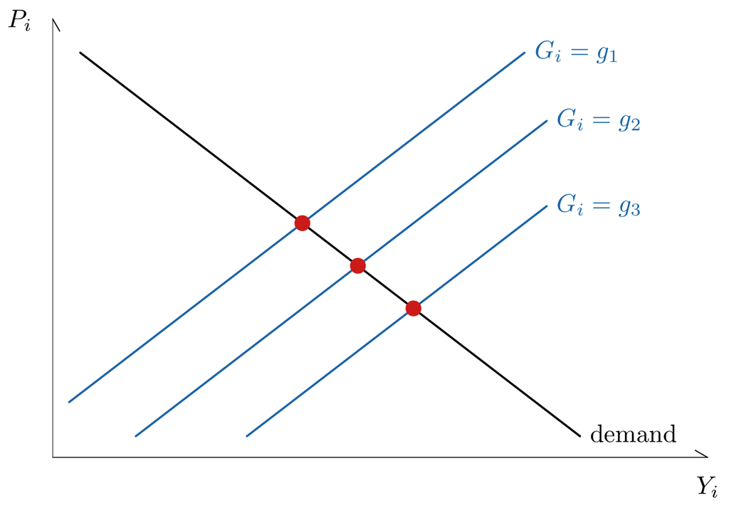

- Equilibria lie on one demand curve $\Longrightarrow$ demand curve identified.

## Example: Angrist and Evans (1998)

- Angrist, J. D. and W. N. Evans (1998). “Children and Their Parents’ Labor Supply: Evidence from Exogenous Variation in Family Size.” *American Economic Review* 88(3), 450–477.
- Married women with at least 2 children:
  $$\begin{aligned}
  \text{Hours worked}_i &= \beta_1\, \text{Number of children}_i + X_{i,2}^\top \beta_2 + U_i \\
  \text{Number of children}_i &= \gamma_1\, \text{Hours worked}_i + \gamma_2\, {\color{red} \text{Same sex}_i} + X_{i,2}^\top \gamma_3 + U_i^c
  \end{aligned}$$
- $X_{i,2}$: mother’s age, age at first birth, race, sex of first and second child.
- $\text{Same sex}_i = 1$ if the first two children are both boys or both girls.
- First two children of the same sex $\Longrightarrow$ third child more likely.
- IV for $\text{Number of children}_i$: $\text{Same sex}_i$.
- First stage:
  $$\text{Number of children}_i = \Pi_1\, \text{Same sex}_i + X_{i,2}^\top \Pi_2 + V_i$$
- $\Pi_1 > 0$.

# Generalized method of moments (GMM)

## Weight matrix $W$

- **Definition.** Weight matrix $W$: $\ell \times \ell$, symmetric, p.d.
- Premultiply by $\mathrm{E}\left[X_i Z_i^\top\right] W$:
  $$\begin{aligned}
  & \mathrm{E}\left[Z_i X_i^\top\right] \beta = \mathrm{E}\left[Z_i Y_i\right] \\
  \Longrightarrow\quad & \underbrace{\underset{k \times \ell}{\mathrm{E}\left[X_i Z_i^\top\right]}\ \underset{\ell \times \ell}{W}\ \underset{\ell \times k}{\mathrm{E}\left[Z_i X_i^\top\right]}}_{k \times k}\ \beta = \mathrm{E}\left[X_i Z_i^\top\right] W\, \mathrm{E}\left[Z_i Y_i\right] \\
  \Longrightarrow\quad & \beta = \big(\mathrm{E}\left[X_i Z_i^\top\right] W\, \mathrm{E}\left[Z_i X_i^\top\right]\big)^{-1} \mathrm{E}\left[X_i Z_i^\top\right] W\, \mathrm{E}\left[Z_i Y_i\right]
  \end{aligned}$$
- Same $\beta$ for every p.d. $W$.
- Over-identified case: we used $W = I_\ell$.
- $W$: does not matter for identification, but matters for estimation.
- Different $W$ correspond to different variances of the estimator.
- **Definition.** GMM estimator with weight matrix $W_n$:
  $$\hat\beta(W_n) = (X^\top Z\, W_n\, Z^\top X)^{-1} X^\top Z\, W_n\, Z^\top Y$$

## Exactly identified case: $W$ cancels

- $\ell = k$ $\Longrightarrow$ $W_n$ cancels:
  $$\begin{aligned}
  \hat\beta(W_n) &= ({\color{red} X^\top Z}\, {\color{blue} W_n}\, Z^\top X)^{-1} {\color{red} X^\top Z}\, {\color{blue} W_n}\, Z^\top Y \\
  &= (Z^\top X)^{-1}\, {\color{blue} W_n^{-1}}\, {\color{red} (X^\top Z)^{-1} X^\top Z}\, {\color{blue} W_n}\, Z^\top Y \\
  &= (Z^\top X)^{-1} Z^\top Y \\
  &= \hat\beta^{IV}
  \end{aligned}$$
- $\mathrm{E}\left[Z_i X_i^\top\right]$, $W$: $k \times k$, invertible.
- Population version:
  $$\begin{aligned}
  \beta &= \big(\underset{k \times k}{{\color{red} \mathrm{E}\left[X_i Z_i^\top\right]}}\ \underset{k \times k}{{\color{blue} W}}\ \underset{k \times k}{\mathrm{E}\left[Z_i X_i^\top\right]}\big)^{-1}\, \underset{k \times k}{{\color{red} \mathrm{E}\left[X_i Z_i^\top\right]}}\ \underset{k \times k}{{\color{blue} W}}\, \mathrm{E}\left[Z_i Y_i\right] \\
  &= \big(\mathrm{E}\left[Z_i X_i^\top\right]\big)^{-1}\, {\color{blue} W^{-1}}\, {\color{red} \big(\mathrm{E}\left[X_i Z_i^\top\right]\big)^{-1} \mathrm{E}\left[X_i Z_i^\top\right]}\, {\color{blue} W}\, \mathrm{E}\left[Z_i Y_i\right] \\
  &= \big(\mathrm{E}\left[Z_i X_i^\top\right]\big)^{-1} \mathrm{E}\left[Z_i Y_i\right]
  \end{aligned}$$

## Linear GMM model

- Linear GMM estimator:
  $$\hat\beta(W_n) = (X^\top Z\, W_n\, Z^\top X)^{-1} X^\top Z\, W_n\, Z^\top Y$$
- **Assumption I.**
  - $\{(Y_i, X_i, Z_i) : i = 1, \ldots, n\}$ iid.
  - $Y_i = X_i^\top \beta + U_i$, $\beta \in \mathbb{R}^k$.
- **Assumption II.** $\mathrm{E}\left[Z_i U_i\right] = 0$.
- **Assumption III.** $\operatorname{rank}\left(\mathrm{E}\left[Z_i X_i^\top\right]\right) = k$.
- **Assumption IV.**
  - $W_n \to_p W$.
  - $W$: $\ell \times \ell$, symmetric, p.d.

## Consistency of $\hat\beta(W_n)$

- Linear GMM estimator:
  $$\hat\beta(W_n) = (X^\top Z\, W_n\, Z^\top X)^{-1} X^\top Z\, W_n\, Z^\top Y$$
- Weak LLN, Assumptions I and II:
  $$\begin{aligned}
  \frac{Z^\top X}{n} &= \frac{1}{n} \sum_{i=1}^n Z_i X_i^\top \to_p \mathrm{E}\left[Z_i X_i^\top\right] = Q \\
  \frac{Z^\top U}{n} &= \frac{1}{n} \sum_{i=1}^n Z_i U_i \to_p \mathrm{E}\left[Z_i U_i\right] = 0
  \end{aligned}$$
- Slutsky, Assumptions III and IV:
  $$\Big(\frac{X^\top Z}{n}\, W_n\, \frac{Z^\top X}{n}\Big)^{-1} \to_p (Q^\top W Q)^{-1}$$
- **Theorem.** Under Assumptions I to IV:
  $$\begin{aligned}
  \hat\beta(W_n) &= \beta + (X^\top Z\, W_n\, Z^\top X)^{-1} X^\top Z\, W_n\, Z^\top U \qquad (Y = X\beta + U) \\
  &= \beta + \underbrace{\Big(\frac{X^\top Z}{n}\, W_n\, \frac{Z^\top X}{n}\Big)^{-1}}_{\to_p\, (Q^\top W Q)^{-1}}\ \underbrace{\frac{X^\top Z}{n}\, W_n}_{\to_p\, Q^\top W}\ \underbrace{\frac{Z^\top U}{n}}_{\to_p\, 0} \\
  &\to_p \beta
  \end{aligned}$$

## CLT for $Z^\top U / \sqrt{n}$

- **Assumption V.** $\Omega = \mathrm{E}\left[U_i^2 Z_i Z_i^\top\right]$ finite and p.d.
- Variance of $Z_i U_i$, with $\mathrm{E}\left[Z_i U_i\right] = 0$:
  $$\begin{aligned}
  \Omega &= \mathrm{Var}\left(Z_i U_i\right) \\
  &= \mathrm{E}\left[Z_i U_i (Z_i U_i)^\top\right] \\
  &= \mathrm{E}\left[U_i^2 Z_i Z_i^\top\right]
  \end{aligned}$$
- $Z_1 U_1, \ldots, Z_n U_n$: iid.
- Multivariate CLT:
  $$\frac{Z^\top U}{\sqrt{n}} = \frac{1}{\sqrt{n}} \sum_{i=1}^n Z_i U_i \to_d N(0, \Omega)$$

## Asymptotic variance of $\hat\beta(W_n)$

- Multiply the representation of $\hat\beta(W_n) - \beta$ by $\sqrt{n}$:
  $$\begin{aligned}
  \sqrt{n}\big(\hat\beta(W_n) - \beta\big) &= \underbrace{\Big(\frac{X^\top Z}{n}\, W_n\, \frac{Z^\top X}{n}\Big)^{-1}}_{\to_p\, (Q^\top W Q)^{-1}}\ \underbrace{\frac{X^\top Z}{n}\, W_n}_{\to_p\, Q^\top W}\ \underbrace{\frac{Z^\top U}{\sqrt{n}}}_{\to_d\, N(0, \Omega)} \\
  &\to_d (Q^\top W Q)^{-1} Q^\top W\, N(0, \Omega) \\
  &\overset{d}{=} N\big(0,\ \underbrace{(Q^\top W Q)^{-1} Q^\top W \Omega W Q (Q^\top W Q)^{-1}}_{V(W)}\big) \qquad (W,\ Q^\top W Q \ \text{symmetric})
  \end{aligned}$$
- **Theorem.** Under Assumptions I to V:
  $$\sqrt{n}\big(\hat\beta(W_n) - \beta\big) \to_d N\big(0, V(W)\big), \qquad V(W) = \mathrm{AsyVar}\big(\hat\beta(W_n)\big)$$

## Efficient weight matrix $W^* = \Omega^{-1}$

- **Definition.** Efficient weight matrix $W^*$: minimizes $V(W)$ in the p.s.d. sense:
  $$V(W) - V(W^*) \ge 0 \quad \text{(p.s.d.) for every } W$$
- **Claim.** $W^* = \Omega^{-1}$.
- $V({\color{blue} W})$ at ${\color{blue} W} = {\color{blue} \Omega^{-1}}$:
  $$\begin{aligned}
  V({\color{blue} \Omega^{-1}}) &= (Q^\top {\color{blue} \Omega^{-1}} Q)^{-1}\ \underbrace{Q^\top {\color{blue} \Omega^{-1}}\, \Omega\, {\color{blue} \Omega^{-1}} Q}_{=\, Q^\top {\color{blue} \Omega^{-1}} Q}\ (Q^\top {\color{blue} \Omega^{-1}} Q)^{-1} \\
  &= (Q^\top {\color{blue} \Omega^{-1}} Q)^{-1}
  \end{aligned}$$

## Interpretation of $W^* = \Omega^{-1}$

- Variance of the moment conditions that identify $\beta$:
  $$\Omega = \mathrm{Var}\left(Z_i U_i\right) = \mathrm{Var}\left(Z_i (Y_i - X_i^\top \beta)\right)$$
- $W^* = \Omega^{-1}$: more weight to less noisy moment conditions.
- Same principle as GLS.

## Proof that $W^* = \Omega^{-1}$ is efficient

- Matrices, p.s.d. differences:
  $$\begin{aligned}
  & V(W) - V(\Omega^{-1}) \ge 0 \\
  \Longleftrightarrow\quad & \big(V(\Omega^{-1})\big)^{-1} - \big(V(W)\big)^{-1} \ge 0
  \end{aligned}$$
- Difference of the inverses:
  $$\begin{aligned}
  \big(V(\Omega^{-1})\big)^{-1} - \big(V(W)\big)^{-1} &= Q^\top \Omega^{-1} Q - (Q^\top W Q)(Q^\top W \Omega W Q)^{-1}(Q^\top W Q) \\
  &= Q^\top \Omega^{-1/2} \Big(I - \underbrace{\Omega^{1/2} W Q}_{H}\, \big(\underbrace{Q^\top W \Omega W Q}_{H^\top H}\big)^{-1} \underbrace{Q^\top W \Omega^{1/2}}_{H^\top}\Big) \Omega^{-1/2} Q \\
  &= Q^\top \Omega^{-1/2}\, \underbrace{\big(I - H (H^\top H)^{-1} H^\top\big)}_{M_H}\, \Omega^{-1/2} Q \\
  &= Q^\top \Omega^{-1/2}\, \underbrace{M_H}_{\text{p.s.d.}}\, \Omega^{-1/2} Q \\
  &\ge 0
  \end{aligned}$$
- Recall: $M_H$: symmetric, idempotent, p.s.d.

## Two-step efficient GMM

- Efficient weight matrix, unknown:
  $$W^* = \Omega^{-1} = \big(\mathrm{E}\left[U_i^2 Z_i Z_i^\top\right]\big)^{-1}$$
- Step 1: $W_n = I_\ell$.
- $\hat\beta(I_\ell)$ consistent.
- Estimator of $\Omega$ from the residuals of $\hat\beta(I_\ell)$:
  $$\hat\Omega_n = \frac{1}{n} \sum_{i=1}^n \big(Y_i - X_i^\top \hat\beta(I_\ell)\big)^2 Z_i Z_i^\top$$
- Step 2: $W_n = \hat\Omega_n^{-1}$, efficient GMM:
  $$\hat\beta(\hat\Omega_n^{-1}) = (X^\top Z\, \hat\Omega_n^{-1} Z^\top X)^{-1} X^\top Z\, \hat\Omega_n^{-1} Z^\top Y$$
- One can show: $\hat\Omega_n \to_p \Omega$.

## Asymptotic variance of $\hat\beta^{IV}$

- $\ell = k$.
- $Q$: $k \times k$, invertible.
- IV estimator:
  $$\begin{aligned}
  \hat\beta^{IV} &= (\underbrace{Z^\top X}_{k \times k})^{-1} Z^\top Y \\
  &= \beta + (Z^\top X)^{-1} Z^\top U \qquad (Y = X\beta + U)
  \end{aligned}$$
- Cramér convergence theorem:
  $$\begin{aligned}
  \sqrt{n}\big(\hat\beta^{IV} - \beta\big) &= \underbrace{\Big(\frac{Z^\top X}{n}\Big)^{-1}}_{\to_p\, Q^{-1}}\ \underbrace{\frac{Z^\top U}{\sqrt{n}}}_{\to_d\, N(0, \Omega)} \\
  &\to_d Q^{-1}\, N(0, \Omega)
  \end{aligned}$$
- We will use: $(Q^{-1})^\top = (Q^\top)^{-1}$.
- Variance of $Q^{-1} N(0, \Omega)$:
  $$\begin{aligned}
  \mathrm{AsyVar}\big(\hat\beta^{IV}\big) &= Q^{-1}\, \Omega\, (Q^{-1})^\top \\
  &= \boxed{\ \big(\mathrm{E}\left[Z_i X_i^\top\right]\big)^{-1}\, \mathrm{E}\left[U_i^2 Z_i Z_i^\top\right]\, \big(\mathrm{E}\left[X_i Z_i^\top\right]\big)^{-1}\ }
  \end{aligned}$$

# Two-stage least squares (2SLS)

## Homoskedasticity: efficient GMM is 2SLS

- Suppose:
  $$\mathrm{E}\left[U_i^2 \mid Z_i\right] = \sigma^2 \quad \text{(homoskedasticity)}$$
- Law of iterated expectations (LIE):
  $$\begin{aligned}
  \Omega &= \mathrm{E}\left[U_i^2 Z_i Z_i^\top\right] \\
  &\overset{\text{LIE}}{=} \sigma^2\, \mathrm{E}\left[Z_i Z_i^\top\right]
  \end{aligned}$$
- Estimator of $\Omega$:
  $$\hat\Omega_n = \hat\sigma_n^2\, \frac{Z^\top Z}{n}$$
- Efficient GMM:
  $$\begin{aligned}
  \hat\beta(\hat\Omega_n^{-1}) &= \Big(X^\top Z \Big(\hat\sigma_n^2\, \frac{Z^\top Z}{n}\Big)^{-1} Z^\top X\Big)^{-1} X^\top Z \Big(\hat\sigma_n^2\, \frac{Z^\top Z}{n}\Big)^{-1} Z^\top Y \\
  &= \big(X^\top \underbrace{Z (Z^\top Z)^{-1} Z^\top}_{P_Z} X\big)^{-1} X^\top \underbrace{Z (Z^\top Z)^{-1} Z^\top}_{P_Z} Y \\
  &= \boxed{\ (X^\top P_Z X)^{-1} X^\top P_Z Y \equiv \hat\beta^{2SLS}\ }
  \end{aligned}$$
- The scalar $n / \hat\sigma_n^2$ cancels.

## 2SLS: first and second stage

- First stage, fitted values:
  $$\begin{aligned}
  \hat X &= P_Z X \\
  \hat X_i &= \begin{pmatrix} \hat X_{i,1} \\ X_{i,2} \end{pmatrix}
  \end{aligned}$$
- Second stage, OLS of $Y$ on $\hat X$:
  $$\begin{aligned}
  \hat\beta^{2SLS} &= (X^\top P_Z X)^{-1} X^\top P_Z Y \\
  &= (\hat X^\top \hat X)^{-1} \hat X^\top Y
  \end{aligned}$$
- $X_2$: columns of $Z$ $\Longrightarrow$ $P_Z X_2 = X_2$.
- First stage, OLS of $X_{i,1}$ on $Z_i$:
  $$\begin{aligned}
  \hat\Pi &= (Z^\top Z)^{-1} Z^\top X_1 \\
  \hat X_{i,1} &= \hat\Pi^\top Z_i \\
  &= \hat\Pi_1^\top Z_{i,1} + \hat\Pi_2^\top X_{i,2}
  \end{aligned}$$

# Control function and the Hausman test

## Every regressor endogenous

- Model and first stage, $\Pi$: $\ell \times k$:
  $$\begin{aligned}
  Y_i &= X_i^\top \beta + U_i \\
  \underset{k \times 1}{X_i} &= \underset{k \times \ell}{\Pi^\top}\, \underset{\ell \times 1}{Z_i} + \underset{k \times 1}{V_i}
  \end{aligned}$$
- Exogenous instruments:
  $$\mathrm{E}\left[Z_i U_i\right] = 0$$
- $\Pi$ defined so that $Z_i$, $V_i$ uncorrelated:
  $$\mathrm{E}\left[Z_i V_i^\top\right] = 0$$
- $V_i$: the source of endogeneity:
  $$\mathrm{E}\left[X_i U_i\right] \ne 0, \quad \mathrm{E}\left[Z_i U_i\right] = 0 \quad \Longrightarrow \quad \mathrm{E}\left[V_i U_i\right] \ne 0$$

## Decomposition of $U_i$

- **Define:**
  $$\begin{aligned}
  \lambda &= \big(\mathrm{E}\left[V_i V_i^\top\right]\big)^{-1} \mathrm{E}\left[V_i U_i\right] \\
  \varepsilon_i &= U_i - V_i^\top \lambda \\
  \Longrightarrow\quad & \boxed{U_i = V_i^\top \lambda + \varepsilon_i}
  \end{aligned}$$
- $V_i$ and $\varepsilon_i$ uncorrelated:
  $$\begin{aligned}
  \mathrm{E}\left[V_i \varepsilon_i\right] &= \mathrm{E}\left[V_i U_i\right] - \mathrm{E}\left[V_i V_i^\top\right] \lambda \\
  &= \mathrm{E}\left[V_i U_i\right] - {\color{red} \mathrm{E}\left[V_i V_i^\top\right] \big(\mathrm{E}\left[V_i V_i^\top\right]\big)^{-1}} \mathrm{E}\left[V_i U_i\right] \\
  &= 0
  \end{aligned}$$
- Write:
  $$Y_i = X_i^\top \beta + \underbrace{V_i^\top \lambda + \varepsilon_i}_{U_i}$$
- We decompose $U_i$ into a part correlated with $X_i$ and a part uncorrelated with $X_i$.

## OLS with control functions

- Substitute $U_i = V_i^\top \lambda + \varepsilon_i$:
  $$\begin{aligned}
  Y_i &= X_i^\top \beta + V_i^\top \lambda + \varepsilon_i \\
  \mathrm{E}\left[X_i \varepsilon_i\right] &= 0 \\
  \mathrm{E}\left[V_i \varepsilon_i\right] &= 0
  \end{aligned}$$
- $Z_i$ and $\varepsilon_i$ uncorrelated:
  $$\begin{aligned}
  \mathrm{E}\left[Z_i \varepsilon_i\right] &= \mathrm{E}\left[Z_i (U_i - V_i^\top \lambda)\right] \\
  &= \underbrace{\mathrm{E}\left[Z_i U_i\right]}_{=\,0} - \underbrace{\mathrm{E}\left[Z_i V_i^\top\right]}_{=\,0} \lambda \\
  &= 0
  \end{aligned}$$
- $X_i$ and $\varepsilon_i$ uncorrelated:
  $$\begin{aligned}
  \mathrm{E}\left[X_i \varepsilon_i\right] &= \mathrm{E}\left[(\Pi^\top Z_i + V_i)\, \varepsilon_i\right] \\
  &= \Pi^\top \underbrace{\mathrm{E}\left[Z_i \varepsilon_i\right]}_{=\,0} + \underbrace{\mathrm{E}\left[V_i \varepsilon_i\right]}_{=\,0} \\
  &= 0
  \end{aligned}$$
- No endogeneity.
- $V_i$: **control function**: extra regressor we need to control for so that $X_i$ becomes exogenous.
- Function, not regressor: $V_i$ unobserved, needs to be estimated and constructed.

## Control function (CF) estimator

- First-stage residuals:
  $$\begin{aligned}
  \hat V_i &= X_i - \hat\Pi^\top Z_i, \qquad \hat\Pi = (Z^\top Z)^{-1} Z^\top X \\
  \hat V &= X - Z \hat\Pi = X - P_Z X = M_Z X
  \end{aligned}$$
- CF estimator, OLS of $Y_i$ on $X_i$ and $\hat V_i$:
  $$Y_i = X_i^\top \hat\beta^{CF} + \hat V_i^\top \hat\lambda + \hat\varepsilon_i$$
- **Claim.** $\hat\beta^{CF} = \hat\beta^{2SLS}$.

## Proof that $\hat\beta^{CF} = \hat\beta^{2SLS}$

- Matrix form:
  $$\underset{n \times 1}{Y} = \underset{n \times k}{X} \hat\beta^{CF} + \hat V \hat\lambda + \hat\varepsilon, \qquad \boxed{\hat V = M_Z X}$$
- Recall, partitioned regression:
  $$\hat\beta^{CF} = (X^\top M_{\hat V} X)^{-1} X^\top M_{\hat V} Y, \qquad \text{where } M_{\hat V} = I_n - \hat V (\hat V^\top \hat V)^{-1} \hat V^\top$$
- Definition of 2SLS:
  $$\hat\beta^{2SLS} = (X^\top P_Z X)^{-1} X^\top P_Z Y$$
- $M_{\hat V} = I_n - \hat V (\hat V^\top \hat V)^{-1} \hat V^\top$:
  $$\begin{aligned}
  X^\top M_{\hat V} X &= X^\top \big(I_n - \hat V (\hat V^\top \hat V)^{-1} \hat V^\top\big) X \\
  &= X^\top X - X^\top \hat V (\hat V^\top \hat V)^{-1} \hat V^\top X \\
  &= X^\top X - X^\top \underbrace{M_Z X}_{\hat V} \big(\underbrace{X^\top M_Z}_{\hat V^\top} \underbrace{M_Z X}_{\hat V}\big)^{-1} \underbrace{X^\top M_Z}_{\hat V^\top} X \\
  &= X^\top X - X^\top M_Z X\, {\color{red} (X^\top M_Z X)^{-1} X^\top M_Z X} \\
  &= X^\top (I_n - M_Z) X \\
  &= X^\top P_Z X
  \end{aligned}$$
- Same steps, with $Y$ in place of the last $X$:
  $$X^\top M_{\hat V} Y = X^\top P_Z Y$$
- Hence:
  $$\boxed{\ \hat\beta^{CF} = (X^\top P_Z X)^{-1} X^\top P_Z Y = \hat\beta^{2SLS}\ }$$

## Hausman test of exogeneity

- $\hat\lambda$: estimator of $\lambda = \big(\mathrm{E}\left[V_i V_i^\top\right]\big)^{-1} \mathrm{E}\left[V_i U_i\right]$.
- Exogeneity of the regressors in terms of $\lambda$:
  $$\begin{aligned}
  \lambda = 0 \quad &\Longleftrightarrow \quad \mathrm{E}\left[V_i U_i\right] = 0 \\
  &\Longleftrightarrow \quad \mathrm{E}\left[X_i U_i\right] = 0 \qquad (\mathrm{E}\left[X_i U_i\right] = \Pi^\top \mathrm{E}\left[Z_i U_i\right] + \mathrm{E}\left[V_i U_i\right])
  \end{aligned}$$
- Hypotheses:
  $$H_0: \lambda = 0 \ \ (X_i \ \text{exogenous}) \qquad \text{vs} \qquad H_1: \lambda \ne 0 \ \ (X_i \ \text{endogenous})$$
- Under $H_0$, one can show:
  $$H_n = n\, \hat\lambda^\top \big[\widehat{\mathrm{AsyVar}}(\hat\lambda)\big]^{-1} \hat\lambda \to_d \chi^2_{k_1}, \qquad k_1: \ \text{number of endogenous regressors}$$
- Reject $H_0$: $H_n > \chi^2_{k_1,\, 1-\alpha}$.

# Over-identifying restrictions test

## Exactly identified case: $Z^\top \hat U = 0$

- $\ell = k$.
- $\hat U = Y - X \hat\beta^{IV}$, $\hat\beta^{IV} = (Z^\top X)^{-1} Z^\top Y$:
  $$\begin{aligned}
  Z^\top \hat U &= Z^\top Y - Z^\top X \hat\beta^{IV} \\
  &= Z^\top Y - {\color{red} Z^\top X (Z^\top X)^{-1}} Z^\top Y \\
  &= 0
  \end{aligned}$$
- Over-identified case, $\ell > k$: $Z^\top \hat U \ne 0$, but close to zero if $\mathrm{E}\left[Z_i U_i\right] = 0$.

## Hypotheses and efficient GMM

- When $\ell > k$:
  $$\begin{aligned}
  H_0 &: \ \mathrm{E}\left[Z_i (Y_i - X_i^\top \beta)\right] = 0 \quad \text{for some } \beta \in \mathbb{R}^k \\
  H_1 &: \ \mathrm{E}\left[Z_i (Y_i - X_i^\top b)\right] \ne 0 \quad \text{for all } b \in \mathbb{R}^k
  \end{aligned}$$
- $\hat\beta = \hat\beta(\hat\Omega_n^{-1})$: efficient GMM.
- $\hat U_i = Y_i - X_i^\top \hat\beta$.
- $\hat\Omega_n^{-1}$-weighted distance of $\frac{1}{n} \sum_{i=1}^n Z_i \hat U_i$ from zero:
  $$\begin{aligned}
  J &= \frac{1}{n} (Y - X\hat\beta)^\top Z\ \hat\Omega_n^{-1}\ \frac{1}{n} Z^\top (Y - X\hat\beta) \\
  &= \Big(\frac{1}{n} \sum_{i=1}^n Z_i \hat U_i\Big)^\top \hat\Omega_n^{-1} \Big(\frac{1}{n} \sum_{i=1}^n Z_i \hat U_i\Big)
  \end{aligned}$$
- $\ell = k$: $\hat\beta = \hat\beta^{IV}$, $Z^\top \hat U = 0$ $\Longrightarrow$ $J = 0$, whether $H_0$ is true or false.
- $\ell > k$, $H_0$ true:
  $$\frac{1}{n} \sum_{i=1}^n Z_i \hat U_i \to_p 0 \quad \Longrightarrow \quad J > 0, \ \text{but} \ J \to_p 0$$

## Quadratic form at the true $\beta$

- Under $H_0$, CLT:
  $$\frac{1}{\sqrt{n}} Z^\top (Y - X\beta) = \frac{1}{\sqrt{n}} \sum_{i=1}^n Z_i U_i \to_d N(0, \Omega)$$
- $\hat\Omega_n^{-1} = \Omega^{-1} + o_p(1)$:
  $$\frac{(Y - X\beta)^\top Z}{\sqrt{n}}\, \hat\Omega_n^{-1}\, \frac{Z^\top (Y - X\beta)}{\sqrt{n}} = \frac{U^\top Z}{\sqrt{n}}\, \Omega^{-1}\, \underbrace{\frac{Z^\top U}{\sqrt{n}}}_{\to_d\, N(0, \Omega)} + o_p(1)$$
- For $x \in \mathbb{R}^\ell$:
  $$\begin{aligned}
  x^\top \Omega^{-1} x &= x^\top \Omega^{-1/2}\, \Omega^{-1/2} x \\
  &= (\Omega^{-1/2} x)^\top\, \Omega^{-1/2} x \\
  &= \|\Omega^{-1/2} x\|^2
  \end{aligned}$$
- Continue, with $x = Z^\top U / \sqrt{n}$:
  $$\begin{aligned}
  \frac{(Y - X\beta)^\top Z}{\sqrt{n}}\, \hat\Omega_n^{-1}\, \frac{Z^\top (Y - X\beta)}{\sqrt{n}} &= \Big\|\underbrace{\Omega^{-1/2}\, \frac{Z^\top U}{\sqrt{n}}}_{\to_d\, \Omega^{-1/2} N(0, \Omega)\, =\, \mathcal{Z}}\Big\|^2 + o_p(1) \\
  &\to_d \|\mathcal{Z}\|^2
  \end{aligned}$$
- $\mathcal{Z} = \Omega^{-1/2} N(0, \Omega) \sim N(0, I_\ell)$:
  $$\begin{aligned}
  \|\mathcal{Z}\|^2 &= \mathcal{Z}^\top \mathcal{Z} \\
  &= \sum_{j=1}^\ell \mathcal{Z}_j^2 \sim \chi^2_\ell
  \end{aligned}$$

## $J$ test and Sargan’s test

- Under $H_0$, one can show, with $\hat\beta$ efficient GMM:
  $$nJ = \frac{(Y - X\hat\beta)^\top Z}{\sqrt{n}}\, \hat\Omega_n^{-1}\, \frac{Z^\top (Y - X\hat\beta)}{\sqrt{n}} \to_d \chi^2_{\ell - k}$$
- $k$ IVs used to estimate $\beta$, $\ell - k$ IVs used to test.
- Test: reject $H_0$ when $nJ > \chi^2_{\ell - k,\, 1-\alpha}$.
- $\mathrm{E}\left[U_i^2 \mid Z_i\right] = \sigma^2$ $\Longrightarrow$ $\hat\Omega_n = \hat\sigma_n^2\, \frac{Z^\top Z}{n}$, $\hat\beta = \hat\beta^{2SLS}$.
- Then $J$ test: Sargan’s test.

# Constructing more instruments

## Functions of exogenous variables as instruments

- Suppose:
  $$\mathrm{E}\left[U_i \mid X_{i,2}, Z_{i,1}\right] = 0$$
- Law of iterated expectations, any function $h$:
  $$\begin{aligned}
  \mathrm{E}\left[h(X_{i,2}, Z_{i,1})\, U_i\right] &= \mathrm{E}\left[\mathrm{E}\left[h(X_{i,2}, Z_{i,1})\, U_i \mid X_{i,2}, Z_{i,1}\right]\right] \\
  &= \mathrm{E}\left[h(X_{i,2}, Z_{i,1})\, \underbrace{\mathrm{E}\left[U_i \mid X_{i,2}, Z_{i,1}\right]}_{=\,0}\right] \\
  &= 0
  \end{aligned}$$
- $Z_{i,1}$: IVs $\Longrightarrow$ products of entries of $Z_{i,1}$ and $X_{i,2}$: IVs too.

# Summary

## Endogeneity and identification

- $\mathrm{E}\left[X_{i,1} U_i\right] \ne 0$ $\Longrightarrow$ OLS inconsistent.
- $k_1 = 1$: $\mathrm{AsyBias}(\hat\beta_1) = \mathrm{E}\left[X_{i,1} U_i\right] / Q_{1 \cdot 2}$.
- $k_1 = 1$: $\hat\beta_2$ also asymptotically biased unless $\mathrm{E}\left[X_{i,2} X_{i,1}\right] = 0$.
- $Z_i = (Z_{i,1}^\top, X_{i,2}^\top)^\top$.
- $\mathrm{E}\left[Z_i (Y_i - X_i^\top \beta)\right] = 0$: $\ell$ equations, $k$ unknowns.
- Rank condition $\operatorname{rank}\left(\mathrm{E}\left[Z_i X_i^\top\right]\right) = k$ $\Longleftrightarrow$ $\operatorname{rank}\left(\Pi_1\right) = k_1$.
- Order condition $\ell_1 \ge k_1$.
- $Z_{i,1}$: excluded, exogenous, informative.
- $\ell = k$: $\hat\beta^{IV} = (Z^\top X)^{-1} Z^\top Y$.

## GMM and 2SLS

- $\hat\beta(W_n) = (X^\top Z W_n Z^\top X)^{-1} X^\top Z W_n Z^\top Y$.
- Assumptions I to IV $\Longrightarrow$ $\hat\beta(W_n) \to_p \beta$.
- Assumptions I to V $\Longrightarrow$ $\sqrt{n}(\hat\beta(W_n) - \beta) \to_d N(0, V(W))$.
- $V(W) = (Q^\top W Q)^{-1} Q^\top W \Omega W Q (Q^\top W Q)^{-1}$.
- Efficient weight matrix: $W^* = \Omega^{-1}$, $V(\Omega^{-1}) = (Q^\top \Omega^{-1} Q)^{-1}$.
- Two-step efficient GMM: $\hat\Omega_n$ from $\hat\beta(I_\ell)$.
- $\ell = k$ $\Longrightarrow$ $\hat\beta(W_n) = \hat\beta^{IV}$.
- $\mathrm{AsyVar}(\hat\beta^{IV}) = Q^{-1} \Omega (Q^{-1})^\top$.
- $\mathrm{E}\left[U_i^2 \mid Z_i\right] = \sigma^2$ $\Longrightarrow$ efficient GMM $= \hat\beta^{2SLS} = (X^\top P_Z X)^{-1} X^\top P_Z Y = (\hat X^\top \hat X)^{-1} \hat X^\top Y$.
- $\hat X = P_Z X$.

## Control function and specification tests

- $U_i = V_i^\top \lambda + \varepsilon_i$: $Y_i = X_i^\top \beta + V_i^\top \lambda + \varepsilon_i$.
- $\mathrm{E}\left[X_i \varepsilon_i\right] = 0$, $\mathrm{E}\left[V_i \varepsilon_i\right] = 0$.
- $\hat\beta^{CF} = \hat\beta^{2SLS}$.
- Hausman:
  - $H_0: \lambda = 0$.
  - $H_n \to_d \chi^2_{k_1}$ under $H_0$.
  - Reject when $H_n > \chi^2_{k_1,\, 1-\alpha}$.
- Over-identifying restrictions, $\ell > k$:
  - $nJ \to_d \chi^2_{\ell - k}$ under $H_0$.
  - Reject when $nJ > \chi^2_{\ell - k,\, 1-\alpha}$.
  - Homoskedasticity $\Longrightarrow$ Sargan’s test.
- $\mathrm{E}\left[U_i \mid X_{i,2}, Z_{i,1}\right] = 0$ $\Longrightarrow$ $\mathrm{E}\left[h(X_{i,2}, Z_{i,1})\, U_i\right] = 0$: functions of $X_{i,2}$, $Z_{i,1}$ as IVs.